# Supervised machine learning

Pablo Barbera

August 9, 2018

### Regularized regression

To learn how to do supervised machine learning applied to social media text, we will use a random sample of nearly 5,000 tweets mentioning the names of the candidates to the 2014 EP elections in the UK. We will be analyzing variable named `communication`, which indicates whether each tweet was hand-coded as being **engaging** (a tweet that tries to engage with the audience of the account) or **broadcasting** (just sending a message, without trying to elicit a response).

The source of the dataset is an article co-authored with Yannis Theocharis, Zoltan Fazekas, and Sebastian Popa, published in the Journal of Communication. The link is [here](http://onlinelibrary.wiley.com/doi/10.1111/jcom.12259/abstract). Our goal was to understand to what extent candidates are not engaging voters on Twitter because they’re exposed to mostly impolite messages.

Let’s start by reading the dataset and creating a dummy variable indicating whether each tweet is engaging

```r
library(quanteda)
tweets <- read.csv("~/data/UK-tweets.csv", stringsAsFactors=F)
tweets$engaging <- ifelse(tweets$communication=="engaging", 1, 0)
tweets <- tweets[!is.na(tweets$engaging),]
```

We’ll do some cleaning as well – substituting handles with @. Why? We want to provent overfitting.

```r
tweets$text <- gsub('@[0-9_A-Za-z]+', '@', tweets$text)
```

As we discussed earlier today, before we can do any type of automated text analysis, we will need to go through several “preprocessing” steps before it can be passed to a statistical model. We’ll use the quanteda package quanteda here.

```r
twcorpus <- corpus(tweets$text)
summary(twcorpus)
```

```
## Corpus consisting of 4566 documents, showing 100 documents:
##
##     Text Types Tokens Sentences
##    text1     8     10         2
##    text2    17     23         3
##    text3    15     18         2
##    text4    15     19         3
##    text5    14     15         1
##    text6     3      3         1
##    text7     9      9         1
##    text8    20     21         2
##    text9    20     23         5
##   text10     8      9         1
##   text11    15     20         1
##   text12    23     27         1
##   text13    16     27         1
##   text14    22     26         2
##   text15    12     19         1
##   text16    21     23         3
##   text17     9     14         1
##   text18    19     23         1
##   text19    16     18         1
##   text20    11     14         1
##   text21     6      6         1
##   text22    14     15         1
##   text23     8     10         1
##   text24     6      7         2
##   text25    29     33         1
##   text26    21     23         3
##   text27    16     18         2
##   text28    17     19         1
##   text29    15     21         1
##   text30    19     21         1
##   text31    20     22         1
##   text32    15     15         1
##   text33     7      7         1
##   text34    22     23         2
##   text35    18     20         2
##   text36    16     16         1
##   text37     9      9         1
```

[output cut: 52 more lines]

```
##   text90    11     13         1
##   text91    19     21         3
##   text92    27     31         3
##   text93    15     17         1
##   text94     5      5         1
##   text95     4      4         1
##   text96    28     29         2
##   text97     5      6         1
##   text98    22     24         1
##   text99    15     21         1
##  text100    24     27         1
##
## Source: /Users/pablobarbera/git/ECPR-SC105/code/* on x86_64 by pablobarbera
## Created: Thu Aug  9 11:08:16 2018
## Notes:
```

We can then convert a corpus into a document-feature matrix using the dfm function. We will then trim it in order to keep only tokens that appear in 2 or more tweets. Note that we keep punctuation – it turns out it can be quite informative.

```r
twdfm <- dfm(twcorpus, remove=stopwords("english"), remove_url=TRUE,
             ngrams=1:2, verbose=TRUE)
```

```
## Creating a dfm from a corpus input...
```

```
##    ... lowercasing
```

```
##    ... found 4,566 documents, 48,657 features
```

```
##    ... removed 169 features
##    ... created a 4,566 x 48,488 sparse dfm
##    ... complete.
## Elapsed time: 1.28 seconds.
```

```r
twdfm <- dfm_trim(twdfm, min_docfreq = 2, verbose=TRUE)
```

```
## Removing features occurring:
##   - in fewer than 2 documents: 38,258
##   Total features removed: 38,258 (78.9%).
```

Note that other preprocessing options are:

- remove_numbers
- remove_punct
- remove_twitter
- remove_symbols
- remove_separators

You can read more in the `dfm` and `tokens` help pages

Once we have the DFM, we split it into training and test set. We’ll go with 80% training and 20% set. Note the use of a random seed to make sure our results are replicable.

```r
set.seed(123)
training <- sample(1:nrow(tweets), floor(.80 * nrow(tweets)))
test <- (1:nrow(tweets))[1:nrow(tweets) %in% training == FALSE]
```

Our first step is to train the classifier using cross-validation. There are many packages in R to run machine learning models. For regularized regression, glmnet is in my opinion the best. It’s much faster than caret or mlr (in my experience at least), and it has cross-validation already built-in, so we don’t need to code it from scratch. We’ll start with a ridge regression:

```r
library(glmnet)
require(doMC)
```

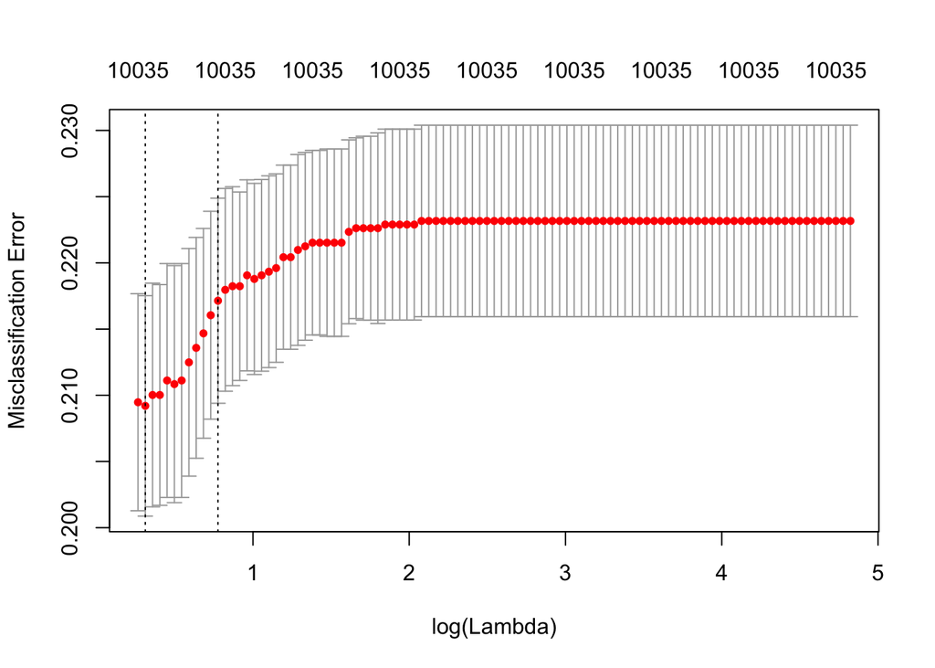

```r
registerDoMC(cores=3)
ridge <- cv.glmnet(twdfm[training,], tweets$engaging[training],
    family="binomial", alpha=0, nfolds=5, parallel=TRUE, intercept=TRUE,
    type.measure="class")
plot(ridge)
```

We can now compute the performance metrics on the test set.

```r
## function to compute accuracy
accuracy <- function(ypred, y){
    tab <- table(ypred, y)
    return(sum(diag(tab))/sum(tab))
}
# function to compute precision
precision <- function(ypred, y){
    tab <- table(ypred, y)
    return((tab[2,2])/(tab[2,1]+tab[2,2]))
}
# function to compute recall
recall <- function(ypred, y){
    tab <- table(ypred, y)
    return(tab[2,2]/(tab[1,2]+tab[2,2]))
}
# computing predicted values
preds <- predict(ridge, twdfm[test,], type="class")
# confusion matrix
table(preds, tweets$engaging[test])
```

```
##
## preds   0   1
##     0  17   3
##     1 176 718
```

```r
# performance metrics
accuracy(preds, tweets$engaging[test])
```

```
## [1] 0.8041575
```

```r
precision(preds==1, tweets$engaging[test]==1)
```

```
## [1] 0.803132
```

```r
recall(preds==1, tweets$engaging[test]==1)
```

```
## [1] 0.9958391
```

```r
precision(preds==0, tweets$engaging[test]==0)
```

```
## [1] 0.85
```

```r
recall(preds==0, tweets$engaging[test]==0)
```

```
## [1] 0.0880829
```

Something that is often very useful is to look at the actual estimated coefficients and see which of these have the highest or lowest values:

```r
# from the different values of lambda, let's pick the highest one that is
# within one standard error of the best one (why? see "one-standard-error"
# rule -- maximizes parsimony)
best.lambda <- which(ridge$lambda==ridge$lambda.1se)
beta <- ridge$glmnet.fit$beta[,best.lambda]
head(beta)
```

```
##            @        thank            !         look          @_@
##  0.026491469  0.057415856  0.009114663 -0.003353636  0.023129622
##      @_thank
##  0.067938135
```

```r
## identifying predictive features
df <- data.frame(coef = as.numeric(beta),
                word = names(beta), stringsAsFactors=F)

df <- df[order(df$coef),]
head(df[,c("coef", "word")], n=30)
```

```
##             coef                  word
## 4412  -0.3378288               reverse
## 9671  -0.3369787              knocking
## 6265  -0.3347340              that_man
## 5764  -0.3330700             and_share
## 262   -0.3303776               and_its
## 2332  -0.3252179                 god_,
## 4026  -0.3211980                beacon
## 8676  -0.3204813               posters
## 4703  -0.3184335                eu_law
## 6448  -0.3178059                  zone
## 6449  -0.3170302               defends
## 6507  -0.3170106             tonbridge
## 8310  -0.3162415       political_class
## 6072  -0.3145641           the_weather
```

[output cut: 16 more lines]

```r
paste(df$word[1:30], collapse=", ")
```

[output not shown]

```r
df <- df[order(df$coef, decreasing=TRUE),]
head(df[,c("coef", "word")], n=30)
```

```
##           coef              word
## 9429 0.1849087         town_hall
## 3412 0.1487278              !_rt
## 7699 0.1486876              dt_@
## 7697 0.1486873                dt
## 9319 0.1483975        west_green
## 6136 0.1483925           western
## 8671 0.1467153            seat_.
## 5143 0.1426298     insignificant
## 4626 0.1354776              re_:
## 5275 0.1307437            vote_-
## 6326 0.1289008            ;_thnx
## 9866 0.1287744            is_big
## 7468 0.1264568            ,_much
## 8435 0.1224417          to_prove
```

[output cut: 16 more lines]

```r
paste(df$word[1:30], collapse=", ")
```

```
## [1] "town_hall, !_rt, dt_@, dt, west_green, western, seat_., insignificant, re_:, vote_-, ;_thnx, is_big, ,_much, to_prove, of_scotland's, :_new, for_tonight, leader_,, bank_of, @_yougov, result_,, @_bbc, ._congratulations, to_labour, !_&, team_!, great_piece, /_eu, addition, compliments"
```

We can easily modify our code to experiment with Lasso or ElasticNet models:

```r
lasso <- cv.glmnet(twdfm[training,], tweets$engaging[training],
    family="binomial", alpha=1, nfolds=5, parallel=TRUE, intercept=TRUE,
    type.measure="class")
```

```r
# computing predicted values
preds <- predict(lasso, twdfm[test,], type="class")
# confusion matrix
table(preds, tweets$engaging[test])
```

```
##
## preds   0   1
##     0  42   6
##     1 151 715
```

```r
# performance metrics (slightly better!)
accuracy(preds, tweets$engaging[test])
```

```
## [1] 0.8282276
```

```r
precision(preds==1, tweets$engaging[test]==1)
```

```
## [1] 0.8256351
```

```r
recall(preds==1, tweets$engaging[test]==1)
```

```
## [1] 0.9916782
```

```r
precision(preds==0, tweets$engaging[test]==0)
```

```
## [1] 0.875
```

```r
recall(preds==0, tweets$engaging[test]==0)
```

```
## [1] 0.2176166
```

```r
best.lambda <- which(lasso$lambda==lasso$lambda.1se)
beta <- lasso$glmnet.fit$beta[,best.lambda]
head(beta)
```

```
##         @     thank         !      look       @_@   @_thank
## 0.6783611 0.0000000 0.0000000 0.0000000 0.0000000 0.0000000
```

```r
## identifying predictive features
df <- data.frame(coef = as.numeric(beta),
                word = names(beta), stringsAsFactors=F)

df <- df[order(df$coef),]
head(df[,c("coef", "word")], n=30)
```

```
##            coef            word
## 601  -1.8190566            on_@
## 9434 -1.8044280     #voteni2014
## 2074 -1.6229927           via_@
## 5326 -1.5450336     #votelabour
## 1375 -1.3048701            to_@
## 282  -1.2989784          with_@
## 1266 -1.2099612           and_@
## 7537 -1.0223134        with_his
## 228  -0.9689621         #ep2014
## 1089 -0.8800491        hustings
## 8786 -0.7803956           far_@
## 109  -0.6992762          hacked
## 9790 -0.6859966             (_@
## 498  -0.6475886 #labourdoorstep
```

[output cut: 16 more lines]

```r
df <- df[order(df$coef, decreasing=TRUE),]
head(df[,c("coef", "word")], n=30)
```

```
##            coef      word
## 558  0.68922703       @_i
## 1    0.67836113         @
## 398  0.46034281    thanks
## 8    0.41625360 thank_you
## 72   0.19778527         ?
## 614  0.17325089    @_good
## 54   0.15182300       :_-
## 399  0.09752179  @_thanks
## 1186 0.07863422     @_yes
## 587  0.07487055      good
## 515  0.01586562     @_you
## 2    0.00000000     thank
## 3    0.00000000         !
## 4    0.00000000      look
```

[output cut: 16 more lines]

We now see that the coefficients for some features actually became zero.

```r
enet <- cv.glmnet(twdfm[training,], tweets$engaging[training],
    family="binomial", alpha=0.50, nfolds=5, parallel=TRUE, intercept=TRUE,
    type.measure="class")
# NOTE: this will not cross-validate across values of alpha

# computing predicted values
preds <- predict(enet, twdfm[test,], type="class")
# confusion matrix
table(preds, tweets$engaging[test])
```

```
##
## preds   0   1
##     0  56  10
##     1 137 711
```

```r
# performance metrics
accuracy(preds, tweets$engaging[test])
```

```
## [1] 0.8391685
```

```r
precision(preds==1, tweets$engaging[test]==1)
```

```
## [1] 0.8384434
```

```r
recall(preds==1, tweets$engaging[test]==1)
```

```
## [1] 0.9861304
```

```r
precision(preds==0, tweets$engaging[test]==0)
```

```
## [1] 0.8484848
```

```r
recall(preds==0, tweets$engaging[test]==0)
```

```
## [1] 0.2901554
```

```r
best.lambda <- which(enet$lambda==enet$lambda.1se)
beta <- enet$glmnet.fit$beta[,best.lambda]
head(beta)
```

```
##         @     thank         !      look       @_@   @_thank
## 0.5962622 0.0000000 0.0000000 0.0000000 0.0000000 0.0000000
```

```r
## identifying predictive features
df <- data.frame(coef = as.numeric(beta),
                word = names(beta), stringsAsFactors=F)

df <- df[order(df$coef),]
head(df[,c("coef", "word")], n=30)
```

```
##            coef              word
## 9434 -1.9397130       #voteni2014
## 601  -1.8435300              on_@
## 3459 -1.7475230              nw_.
## 7537 -1.7255967          with_his
## 5326 -1.7242325       #votelabour
## 2514 -1.4582612 @_#labourdoorstep
## 9790 -1.4446327               (_@
## 2074 -1.3407118             via_@
## 1375 -1.3175990              to_@
## 8786 -1.2491845             far_@
## 282  -1.2335795            with_@
## 1089 -1.1967385          hustings
## 1266 -1.1953930             and_@
## 5928 -1.1647694        just_voted
```

[output cut: 16 more lines]

```r
df <- df[order(df$coef, decreasing=TRUE),]
head(df[,c("coef", "word")], n=30)
```

```
##            coef       word
## 558  0.81795613        @_i
## 1    0.59626220          @
## 8    0.58092430  thank_you
## 398  0.46442642     thanks
## 54   0.37830055        :_-
## 614  0.36000883     @_good
## 1186 0.34125006      @_yes
## 399  0.28964424   @_thanks
## 72   0.25662864          ?
## 515  0.25328467      @_you
## 5630 0.20551387 #votegreen
## 1074 0.17914739      @_the
## 1899 0.15842653    @_great
## 688  0.13645408      @_not
```

[output cut: 16 more lines]